# Phys 434 HW 3 -- Aureliano Liu

```python
%matplotlib inline
import pandas as pd
import numpy as np
import scipy
from scipy import stats
import matplotlib.pyplot as plt
```

## Question 1 A

The the first algorithm (NN) made 8 mistakes in total ; The second algorithm ( NA ) made 12 mistakes in total \ Thus, the NN algorithm made fewer mistakes

## Question 1 B

#### However, for the zoo, NA algorithm is better due to its higher accuracy to identify True birds from mistakenly identified as person

## Question 1 C

So in this case, we have 100 photos, which contains only 1 person and 99 birds.So for both algorithms, \ this person AKA zoo keeper is either identified as Person or Bird

```python
# NN algorithm
d = {'true bird':[93,6],'true person':[0,1]}
df = pd.DataFrame(data=d,index=["NN bird","NN person"])
df
```

|  | true bird | true person |
| --- | --- | --- |
| NN bird | 93 | 0 |
| NN person | 6 | 1 |

```python
# NA algorithm
d = {'true bird':[97,2],'true person':[0,1]}
df = pd.DataFrame(data=d,index=["NA bird","NA person"])
df
```

|  | true bird | true person |
| --- | --- | --- |
| NA bird | 97 | 0 |
| NA person | 2 | 1 |

## Question 2

### Part A :

```python
x = np.linspace(1+stats.expon.ppf(0.01),stats.expon.ppf(0.99),1000)
pdf = stats.expon.pdf(x,1)
```

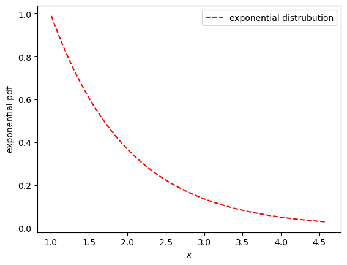

```python
fig,ax = plt.subplots()
ax.plot(x,pdf,'r--',label="exponential distrubution")
ax.set_xlabel("$x$")
ax.set_ylabel("exponential pdf")
ax.legend()
```

```python
def convolv(A,old,count):
    if(count == 1):
        return old
    else:
        temp = np.convolve(A,old)
        return convolv(A,temp,count-1)
```

```python
new_pdf = convolv(pdf,pdf,2)
new_x = np.linspace(1,len(new_pdf),len(new_pdf))
```

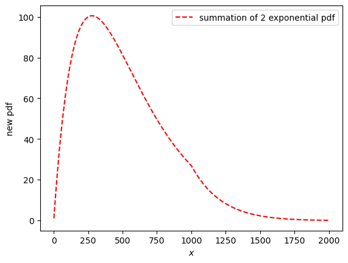

```python
fig1,ax1 = plt.subplots()
ax1.plot(new_x,new_pdf,'r--',label="summation of 2 exponential pdf")
ax1.set_xlabel("$x$")
ax1.set_ylabel("new pdf")
ax1.legend()
```

### Part B

The ratio between two standard normal distributions yield a standard Cauchy distribution

```python
x = np.linspace(stats.cauchy.ppf(0.01),stats.cauchy.ppf(0.99),1000)
pdf = stats.cauchy.pdf(x)
```

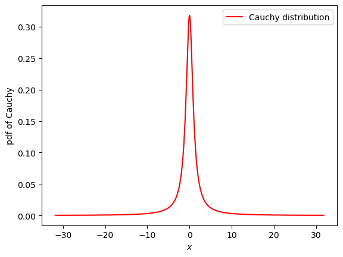

```python
fig,ax = plt.subplots()
ax.plot(x,pdf,'r',label="Cauchy distribution")
ax.set_xlabel("$x$")
ax.set_ylabel("pdf of Cauchy")
ax.legend()
```

```python
x2 = np.linspace(stats.norm.ppf(0.01),stats.norm.ppf(0.99),1000)
pdf = stats.norm.pdf(x)
```

### Part C

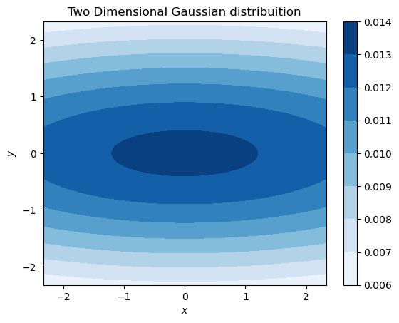

```python
sigma_x = 6.
sigma_y = 2.

x = np.linspace(stats.norm.ppf(0.01), stats.norm.ppf(0.99), 1000)
y = np.linspace(stats.norm.ppf(0.01), stats.norm.ppf(0.99), 1000)

x, y = np.meshgrid(x, y)
z = (1/(2*np.pi*sigma_x*sigma_y) * np.exp(-(x**2/(2*sigma_x**2)
     + y**2/(2*sigma_y**2))))

plt.contourf(x, y, z, cmap='Blues')
plt.title("Two Dimensional Gaussian distribuition")
plt.xlabel("$x$")
plt.ylabel("$y$")
plt.colorbar()
```

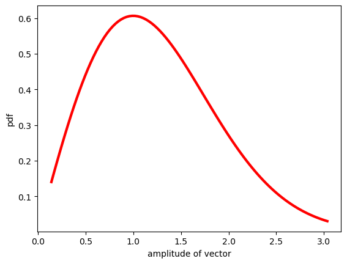

```python
x = np.linspace(stats.rayleigh.ppf(0.01),stats.rayleigh.ppf(0.99),100)
pdf = stats.rayleigh.pdf(x)
fig,ax = plt.subplots()
ax.plot(x,pdf,'r',lw = 3)
ax.set_xlabel("amplitude of vector")
ax.set_ylabel("pdf")
```

#### As sown from the graph above, out Rayleigh pdf is also positive always, which is also consistent with what we expected from measuring the distance